# Лабораторная работа №5

Анализ файловой системы Linux. Команды для работы с файлами и каталогами

Кузнецова София Вадимовна

Российский университет дружбы народов, Москва, Россия

9 марта 2023

# Информация

## Докладчик

- Кузнецова София Вадимовна
- Студенческий билет - 1132227132
- НПИбд-02-22
- Российский университет дружбы народов

# Цели и задачи

Ознакомление с файловой системой Linux, её структурой, именами и содержанием каталогов. Приобретение практических навыков по применению команд для работы с файлами и каталогами, по управлению процессами (и работами), по проверке исполь- зования диска и обслуживанию файловой системы.

# Выполнение лабораторной работы

## Команда cp

Копируем файл /usr/include/sys/io.h в домашний каталог и назовём его equipment, используя команду ср.

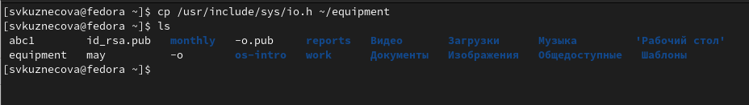

Файл equipment

## Команда mv

Создаём каталог ~/ski.plases и переместив в созданную директорию файл equipment.

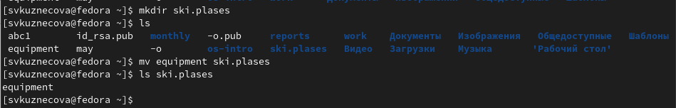

Перемещение файла equipment в каталог ~/ski.plases

## Команда touch

Создаём файл abc1 (команда touch) и копируем его в каталог ski.plases, назовём equiplist2.

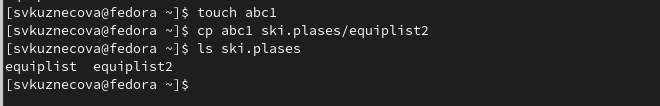

Каталог ski.plases

## Команда chmod

Создаём файлы my_os и feathers и каталоги australia и play, присвоим им следующие права доступа используя команду chmod.

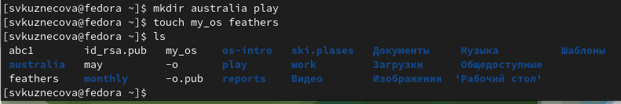

Создание необходимых файлов и каталогов

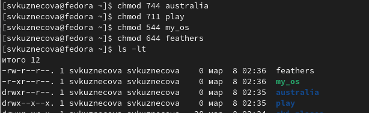

Изиенение прав доступа для файлов и каталогов

## Команда cat

Просмотрим содержимое файла /etc/password.

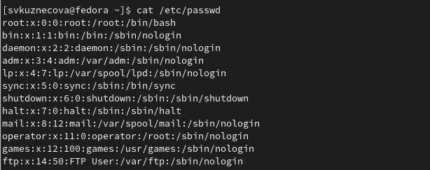

Файл passwd

## Команда mv

Переместим файл ~/file.old в каталог ~/play.

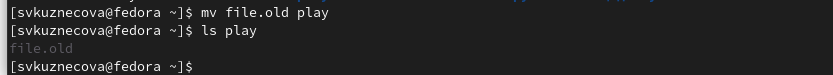

Перемещение файла ~/file.old

## Команда chmod

Лишим владельца файла ~/feathers права на чтение, попробуем просмотреть его и скопировать. В результате без прав на чтение владелец файла не сможет просмотреть и скопировать этот файл.

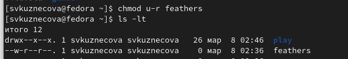

Изменение прав доступа на чтение к файду

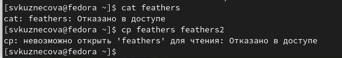

## Команда chmod

Лишаем владельца каталога ~/play права на выполнение и попробуем перейти в него. Без прав на выполнение владнлец не сможет перейти в каталог.Далее восстановим владельцу права на выполнение.

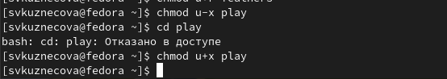

Изменение прав доступа на выполнение каталогу play

## Команда mount

Команда mount используется для просмотра используемых в операциооной системе файловых систем.

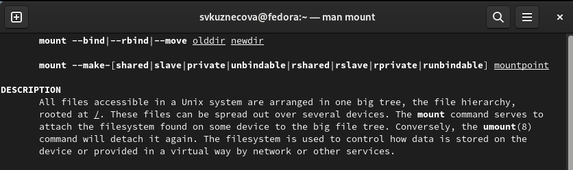

man mount

## Команда fsck

Команда fsck нужна для проверки и восстановления файловой системы.

[figure not shown]

man fsck

## Команда mkfs

Команда mkfs используется для создания файловой системы Linux на устройстве, обычно в разделе диска.

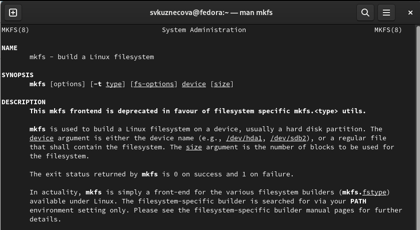

man mkfs

## Команда kill

Команда kill отправляет сигнал процессу, указанному с помощью каждого из операндов идентификатора процесса.

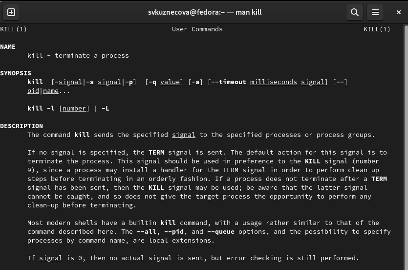

man kill

# Вывод

В ходе выполнения лабораторной работы мы ознакомились с файловой системой Linux, её структурой, именами и содержанием каталогов. Приобрели практические навыки по применению команд для работы с файлами и каталогами, по управлению процессами (и работами), по проверке использования диска и обслуживанию файловой системы.